# Exploring Power Spectra in Time Series (Assignment Sheet 12)

Introduction To Chaos Applied To Systems, Processes And Products (ETSIDI, UPM)

Alfonso Allen-Perkins, Juan Carlos Bueno, and Eduardo Faleiro

2025-05-08

# Introduction

In this assignment, you will explore the **power spectrum** of time series to better understand their frequency characteristics. The power spectrum reveals the contribution of different frequencies to the overall signal — a crucial perspective for identifying periodic, chaotic, or noisy behavior.

# Power spectrum in R

1. Load required libraries

```r
library(tidyverse)
library(nonlinearTseries)
```

2. Load time series data

```r
setwd("C:/Users/alfon/Desktop/Projects/HandsOnChaos")
getwd()
```

```
## [1] "C:/Users/alfon/Desktop/Projects/HandsOnChaos"
```

```r
list.files("Raw-data/Time_series")
```

```
##  [1] "MIT-BIH_SupravArrhyth_801.txt"    "NormalSinusRithm011.txt"
##  [3] "SuddenCardiacDeath35.txt"         "TS_CongesHeartFail211.txt"
##  [5] "TS_deterministic_parabol.txt"     "TS_deterministic_sinx.txt"
##  [7] "TS_logistic.txt"                  "TS_logistic_3.7.txt"
##  [9] "TS_logistic_3.7_x0_0.1.txt"       "TS_logistic_3.7_x0_0.101.txt"
## [11] "TS_MIT-BIH_SupravArrhyth_801.txt" "TS_NormalSinusRithm011.txt"
## [13] "TS_santander.txt"                 "TS_SuddenCardiacDeath35.txt"
```

```r
load_ts <- function(filename) {
  scan(paste0("Raw-data/Time_series/", filename), quiet = TRUE) %>% ts()
}

# Sample time series
ts_d1 <- load_ts("TS_deterministic_parabol.txt")
ts_l2 <- load_ts("TS_logistic_3.7.txt")
ts_ecg1 <- load_ts("NormalSinusRithm011.txt")
ts_stock <- load_ts("TS_santander.txt")


# Create a deterministic sine
omega <- .05*2*pi
x <- 1:1000
ts_d2 <- sin(omega * x) %>% ts()
```

3. Visualize time series

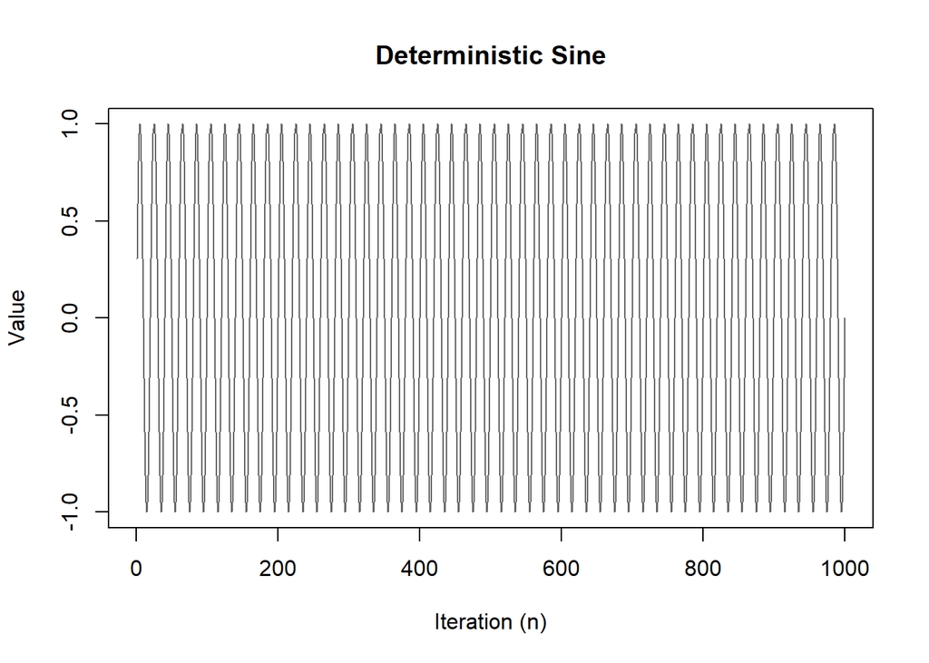

```r
plot(ts_d2, type = "l", col = "grey40",
       main = "Deterministic Sine",
       xlab = "Iteration (n)", ylab = "Value")
```

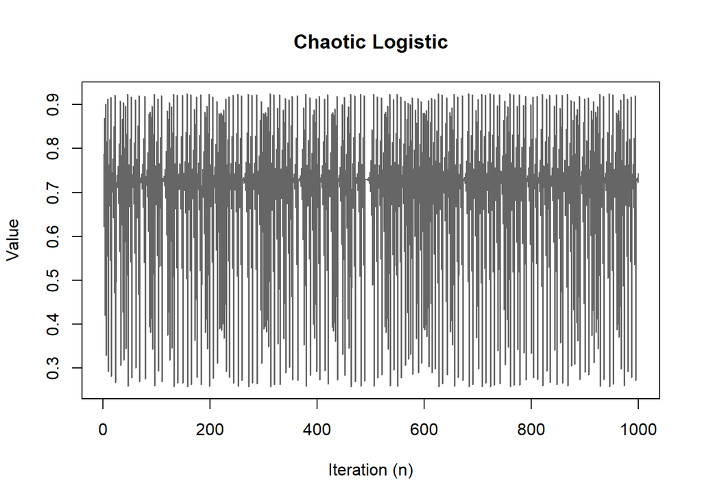

```r
plot(ts_l2, type = "l", col = "grey40",
       main = "Chaotic Logistic",
       xlab = "Iteration (n)", ylab = "Value")
```

4. Power spectrum function

```r
plot_power_spectrum <- function(ts_data, title = "") {
  ts_fft <- fft(ts_data)
  n <- length(ts_data)
  freqs <- (0:(n/2 - 1)) / n
  power <- Mod(ts_fft[1:(n/2)])^2

  plot(freqs, log10(power), type = "l", col = "red",
       main = title,
       xlab = "Frequency", ylab = "Log10(Power)")
}
```

# Comparisson between periodic and chaotic time series

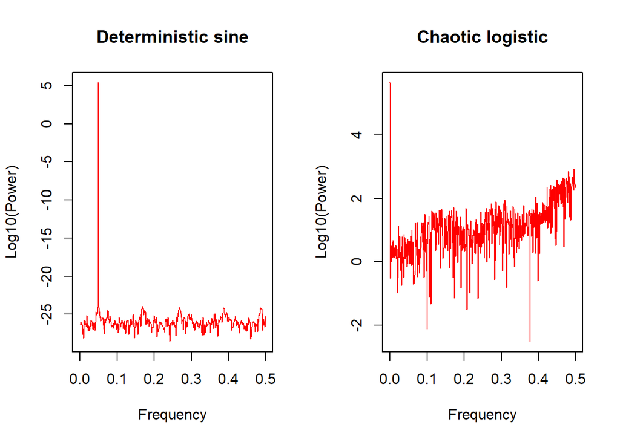

```r
par(mfrow = c(1, 2))
plot_power_spectrum(ts_d2, title = "Deterministic sine")
plot_power_spectrum(ts_l2, title = "Chaotic logistic")
```

```r
par(mfrow = c(1, 1))
```

**Interpretation:**

- The deterministic sine signal shows sharp peaks at specific frequencies, indicating strong periodic components. In the example above, the true frequency of the sine function is:

$f=\frac{\omega}{2\cdot \pi}=\frac{0.05\cdot 2\cdot \pi}{2\cdot \pi}=0.05$,

as shown in the power-spectrum.

- The chaotic logistic series has a broadband spectrum without clear peaks, reflecting irregularity and short-term predictability.

# Task 1: Physiological vs Financial Data

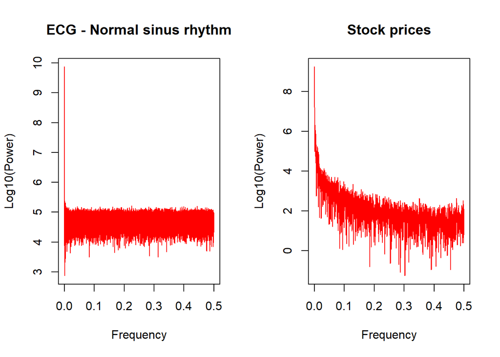

```r
par(mfrow = c(1, 2))
plot_power_spectrum(ts_ecg1, title = "ECG - Normal sinus rhythm")
plot_power_spectrum(ts_stock, title = "Stock prices")
```

```r
par(mfrow = c(1, 1))
```

**Questions:**

- Which signal has more prominent low-frequency components?
- Do either show dominant frequencies? What might this suggest about regularity vs. randomness?

# Optional: Try Log-Log Scaling

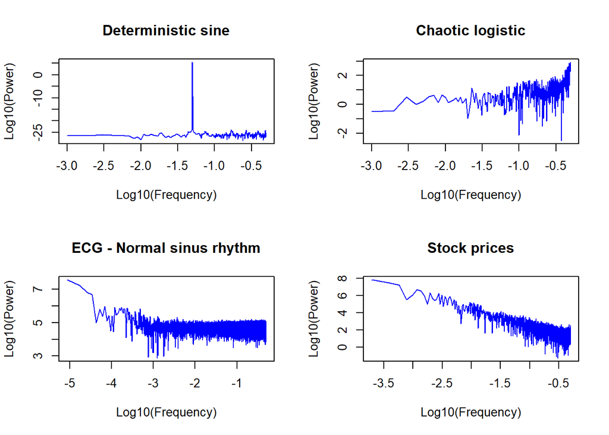

```r
loglog_spectrum <- function(ts_data, title = "") {
  ts_fft <- fft(ts_data)
  n <- length(ts_data)
  freqs <- (0:(n/2 - 1)) / n
  power <- Mod(ts_fft[1:(n/2)])^2

  plot(log10(freqs[-1]), log10(power[-1]), type = "l", col = "blue",
       main = paste(title),
       xlab = "Log10(Frequency)", ylab = "Log10(Power)")
}

par(mfrow = c(2, 2))
loglog_spectrum(ts_d2, "Deterministic sine")
loglog_spectrum(ts_l2, "Chaotic logistic")
loglog_spectrum(ts_ecg1, "ECG - Normal sinus rhythm")
loglog_spectrum(ts_stock, "Stock prices")
```

**Solution:**

The financial time series (Santander stock prices) shows a broadband power spectrum without clear dominant peaks. This suggests highly irregular and stochastic behavior, consistent with market dynamics that are noisy, complex, and difficult to predict.